# Weekly Sales Prediction: A Comparison of Classical ML Methods

The main **objective** of this project is to predict the `Sales` numeric label for a hidden test set, with a dataset that have weekly instances. For it, we will restrain ourselves to **"classical" Machine Learning methods** due to the lack of training data (not neural networks, although a simple one was tested). For achieving this, we define two secondary objectives:

- **Preprocessing**: find the best preprocessing of the data (EDA, understand the relationships between the features, do feature engineering that improves the performance).
- **Best model**: with an adequate train-validation split, find the best model and do the predictions for the hidden test set.

Furthermore, a key part of the project are the **insights**, that will help us understand which features are the most related to the **sales** and how, so it can help in making **future decisions**.

In this notebook every step of the work is detailed. After the setup, an **Exploratory Data Analysis** is performed to fully understand the dataset and the relationships between features. With that information, the **preprocessing** of the data is done, doing key feature engineering for the performance of the future models. Before the creation of the models, more **dataset insights** are extracted thanks to a statistical analysis and the **evaluation method** for selecting the best model is explained. Finally, all the **models** are trained and evaluated, extracting information about the data with each one of them, and the **final predictions** and **conclusions** are detailed.

## Setup

```python
import numpy as np
import pandas as pd
import matplotlib.pyplot as plt
import seaborn as sns
import statsmodels.api as sm
import time
import optuna
import warnings
import shap
import xgboost as xgb

from itertools import combinations

from sklearn.linear_model import LinearRegression, Ridge, Lasso, ElasticNet
from sklearn.metrics import r2_score
from sklearn.model_selection import train_test_split, KFold, cross_val_score
from sklearn.ensemble import RandomForestRegressor, GradientBoostingRegressor, ExtraTreesRegressor
from sklearn.metrics import mean_absolute_error
from sklearn.tree import DecisionTreeRegressor, plot_tree
from sklearn.dummy import DummyRegressor
from sklearn.feature_selection import f_regression, mutual_info_regression
from sklearn.pipeline import Pipeline
from sklearn.preprocessing import StandardScaler
from sklearn.neural_network import MLPRegressor
from sklearn.decomposition import PCA
from sklearn.inspection import PartialDependenceDisplay
from sklearn.exceptions import ConvergenceWarning

from statsmodels.stats.outliers_influence import variance_inflation_factor

pd.options.mode.chained_assignment = None
pd.set_option('display.max_columns', None)
pd.set_option('display.max_rows', None)
pd.set_option('display.max_colwidth', None)

optuna.logging.set_verbosity(optuna.logging.WARNING)  # Set Optuna to not show progress (for tidy outputs when exporting the PDF)
warnings.filterwarnings("ignore", category=ConvergenceWarning)
```

```python
RANDOM_SEED = 100531988  # NIA as random seed
```

Import the full dataset and split it into training data (`data`) and the data for doing the final predictions (`prediction_data`).

```python
full_dataset = pd.read_excel("Real_Dataset_HW2.xlsx")

data = full_dataset[full_dataset['Sales'].notna()]
prediction_data = full_dataset[full_dataset['Sales'].isna()].drop(columns=['Sales'])
```

These are the sizes of the resulting datasets:

```python
print("Full dataset:",full_dataset.shape)
print("\nTraining data:",data.shape)
print("Data for predicting:",prediction_data.shape)
```

```
Full dataset: (142, 15)

Training data: (117, 15)
Data for predicting: (25, 14)
```

## Exploratory Data Analysis

First rows of our dataset:

```python
data.head()
```

|  | Monday_date | Sales | Stores | Affiliates_investment | Meta_investment | sea_brand | sea_other_investment | tiktok_investment | web_visits | GBP | Database_investment | OOH_investment | TV_hbtv_investment | TV_investment | Radio_investment |
| --- | --- | --- | --- | --- | --- | --- | --- | --- | --- | --- | --- | --- | --- | --- | --- |
| 0 | 2022-01-03 | 1784.0 | 343 | 75438.0 | 1507.73 | 5612.98 | 4277.98 | 0.00 | 37616 | 9158 | 13765.0 | 7276.096 | 0.0 | 0.000 | 3990.534594 |
| 1 | 2022-01-10 | 3550.0 | 343 | 31834.0 | 28946.82 | 5889.35 | 7276.61 | 0.00 | 37616 | 12656 | 13765.0 | 7276.096 | 0.0 | 86647.328 | 10451.400127 |
| 2 | 2022-01-17 | 3849.0 | 343 | 16898.0 | 18356.52 | 4363.21 | 8329.27 | 0.00 | 37616 | 11402 | 13765.0 | 7276.096 | 0.0 | 86647.328 | 0.000000 |
| 3 | 2022-01-24 | 4172.0 | 343 | 21278.0 | 6320.86 | 6813.07 | 10015.02 | 2053.84 | 37616 | 11280 | 13765.0 | 7276.096 | 0.0 | 86647.328 | 0.000000 |
| 4 | 2022-01-31 | 3971.0 | 343 | 45546.0 | 13617.16 | 9635.79 | 17285.06 | 250.37 | 46616 | 10415 | 13765.0 | 7276.096 | 0.0 | 86647.328 | 0.000000 |

We can see that the dataset is made from the weekly sales (`Sales`) from a company. In `Monday_date`, the corresponding date of the week monday can be found, while the other features will be our predictors. They are mainly related to investments, probably by the company in different media, so learning about their relationship with the weekly sales is key.

Columns:

```python
columns = list(data.columns)
print(columns)
```

```
['Monday_date', 'Sales', 'Stores', 'Affiliates_investment', 'Meta_investment', 'sea_brand', 'sea_other_investment', 'tiktok_investment', 'web_visits', 'GBP', 'Database_investment', 'OOH_investment', 'TV_hbtv_investment', 'TV_investment', 'Radio_investment']
```

The types of the columns:

```python
data.dtypes
```

```
Monday_date              datetime64[ns]
Sales                           float64
Stores                            int64
Affiliates_investment           float64
Meta_investment                 float64
sea_brand                       float64
sea_other_investment            float64
tiktok_investment               float64
web_visits                        int64
GBP                               int64
Database_investment             float64
OOH_investment                  float64
TV_hbtv_investment              float64
TV_investment                   float64
Radio_investment                float64
dtype: object
```

We can see that they are all correct, so we do not need to make any change of data type.

### Check for NAs

```python
null_counts = full_dataset.isnull().sum()
null_counts_with_values = null_counts[null_counts > 0]

print(null_counts_with_values)
```

```
Sales    25
dtype: int64
```

The only NAs from the full dataset are those corresponding to the response of `prediction_data`, so we will not introduce imputation.

### Statistics

Now, we will get some simple statistic from `pandas`:

```python
data.describe()
```

|  | Monday_date | Sales | Stores | Affiliates_investment | Meta_investment | sea_brand | sea_other_investment | tiktok_investment | web_visits | GBP | Database_investment | OOH_investment | TV_hbtv_investment | TV_investment | Radio_investment |
| --- | --- | --- | --- | --- | --- | --- | --- | --- | --- | --- | --- | --- | --- | --- | --- |
| count | 117 | 117.000000 | 117.000000 | 117.000000 | 117.000000 | 117.000000 | 117.000000 | 117.000000 | 117.000000 | 117.000000 | 117.000000 | 117.000000 | 117.000000 | 117.000000 | 117.000000 |
| mean | 2023-02-13 00:00:00 | 3957.188034 | 371.521368 | 28403.759829 | 29165.363541 | 12339.688547 | 34131.733864 | 527.977350 | 67573.222222 | 10283.145299 | 10364.258803 | 16438.699423 | 3892.955190 | 64742.031944 | 7911.230772 |
| min | 2022-01-03 00:00:00 | 1784.000000 | 343.000000 | 253.700000 | 1507.730000 | 3517.970000 | 4277.980000 | 0.000000 | 22328.000000 | 6888.000000 | 743.750000 | 7193.870000 | 0.000000 | 0.000000 | 0.000000 |
| 25% | 2022-07-25 00:00:00 | 3812.000000 | 362.000000 | 16181.400000 | 20822.680001 | 10236.510000 | 22834.960000 | 0.000000 | 55532.000000 | 9775.000000 | 6847.134579 | 9968.668000 | 0.000000 | 46435.412500 | 0.000000 |
| 50% | 2023-02-13 00:00:00 | 4117.000000 | 377.000000 | 22340.400000 | 28544.389995 | 11898.720000 | 32617.770000 | 147.010000 | 64860.000000 | 10355.000000 | 9806.250000 | 14963.127500 | 6774.193548 | 67331.822500 | 1013.469103 |
| 75% | 2023-09-04 00:00:00 | 4351.000000 | 383.000000 | 40735.800000 | 36811.340005 | 13420.080000 | 41991.350000 | 939.800000 | 80238.000000 | 11091.000000 | 13015.000000 | 22596.360000 | 6818.181818 | 78102.300000 | 13301.781980 |
| max | 2024-03-25 00:00:00 | 4794.000000 | 387.000000 | 93838.000000 | 67471.220000 | 21910.670000 | 83554.116123 | 2345.750000 | 110029.000000 | 12656.000000 | 18637.500000 | 33690.325000 | 7500.002500 | 150346.356000 | 52257.000637 |
| std | NaN | 671.921113 | 13.363356 | 20018.829246 | 12876.893529 | 3575.535707 | 15890.175404 | 669.616015 | 19683.032195 | 1098.004148 | 4155.636175 | 7272.528951 | 3384.177922 | 36787.124806 | 11442.992428 |

```python
prediction_data.describe()
```

|  | Monday_date | Stores | Affiliates_investment | Meta_investment | sea_brand | sea_other_investment | tiktok_investment | web_visits | GBP | Database_investment | OOH_investment | TV_hbtv_investment | TV_investment | Radio_investment |
| --- | --- | --- | --- | --- | --- | --- | --- | --- | --- | --- | --- | --- | --- | --- |
| count | 25 | 25.000000 | 25.000000 | 25.000000 | 25.000000 | 25.000000 | 25.0 | 25.000000 | 25.000000 | 25.000000 | 25.000000 | 25.000000 | 25.000000 | 25.000000 |
| mean | 2024-06-24 00:00:00 | 388.120000 | 15057.516000 | 20024.433150 | 20127.430800 | 61852.932711 | 0.0 | 132667.080000 | 10251.840000 | 12258.987700 | 13233.287820 | 5148.387097 | 56179.368200 | 14640.407443 |
| min | 2024-04-01 00:00:00 | 387.000000 | 2772.000000 | 11022.749993 | 6248.140000 | 29624.940000 | 0.0 | 91544.000000 | 8548.000000 | 5425.000000 | 8181.268000 | 0.000000 | 13870.542500 | 0.000000 |
| 25% | 2024-05-13 00:00:00 | 387.000000 | 5430.000000 | 14074.870001 | 14406.450000 | 41069.500000 | 0.0 | 113097.000000 | 9867.000000 | 7350.000000 | 13022.047500 | 6774.193548 | 47138.912500 | 0.000000 |
| 50% | 2024-06-24 00:00:00 | 388.000000 | 7785.600000 | 18741.360000 | 19424.210000 | 68494.960000 | 0.0 | 122924.000000 | 10383.000000 | 11200.000000 | 13453.820000 | 6774.193548 | 71819.292500 | 0.000000 |
| 75% | 2024-08-05 00:00:00 | 389.000000 | 24681.600000 | 25960.170004 | 29125.570000 | 75271.840000 | 0.0 | 145788.000000 | 10778.000000 | 16800.000000 | 15260.062500 | 6774.193548 | 74574.270000 | 29975.443232 |
| max | 2024-09-16 00:00:00 | 389.000000 | 56137.200000 | 36013.660016 | 36687.180000 | 96212.760000 | 0.0 | 194144.000000 | 11421.000000 | 23974.897500 | 16383.425000 | 6774.193548 | 75717.512500 | 47811.197423 |
| std | NaN | 0.832666 | 15224.836643 | 6343.375293 | 9078.435549 | 19934.387555 | 0.0 | 30982.298244 | 789.161564 | 5812.755889 | 2283.292874 | 2952.802510 | 22182.329232 | 16258.619352 |

Checking the `max` statistic, there are no outliers in the data. Also, we see how the dates for `data` and `prediction_data` are distributed:

- `data`: 2022-01-03 to 2024-03-25
- `prediction_data`: 2024-04-01 to 2024-09-16

### Dependency on the date

**Sales per date**:

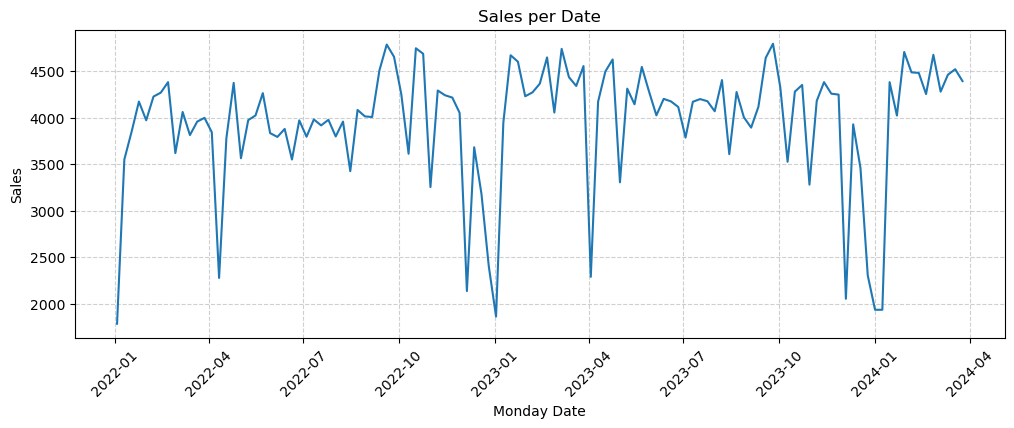

```python
plt.figure(figsize=(12,4))
plt.plot(data['Monday_date'], data['Sales'])
plt.xlabel('Monday Date')
plt.ylabel('Sales')
plt.title('Sales per Date')
plt.xticks(rotation=45)
plt.grid(True, linestyle='--', alpha=0.6)
```

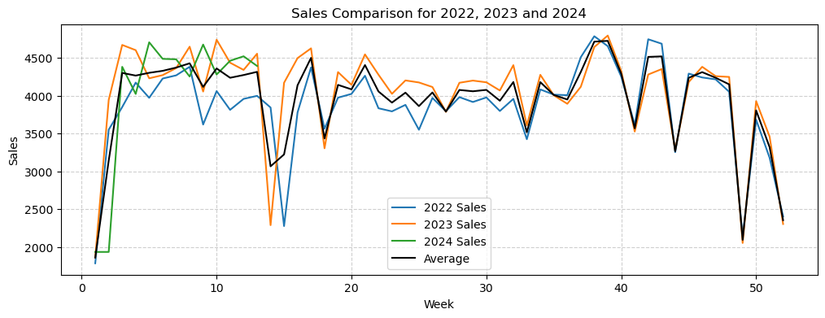

```python
plt.figure(figsize=(12,4))
for year in [2022, 2023, 2024]:
    df = data[data['Monday_date'].dt.year == year]
    df['Week_Number'] = df['Monday_date'].dt.isocalendar().week
    plt.plot(df['Week_Number'], df['Sales'], label=f'{year} Sales')

df = data
df['Week_Number'] = df['Monday_date'].dt.isocalendar().week
weekly_avg_sales = df.groupby('Week_Number')['Sales'].mean()
plt.plot(weekly_avg_sales.index, weekly_avg_sales.values, linestyle='-', color='k', label='Average')

plt.xlabel('Week')
plt.ylabel('Sales')
plt.title('Sales Comparison for 2022, 2023 and 2024')
plt.legend()
plt.grid(True, linestyle='--', alpha=0.6)
```

There are clear signs of **seasonality**.

**Average of sales per week for each year**:

```python
avg_sales_per_year = data.groupby(data['Monday_date'].dt.year)['Sales'].mean()
avg_sales_per_year
```

```
Monday_date
2022    3853.711538
2023    4039.923077
2024    4040.153846
Name: Sales, dtype: float64
```

We have to take into account that the difference between 2022 and 2023 could be random (not showing tendencies) and the value for 2024 is not comparable, as we have only 3 months.

**Sales per month**:

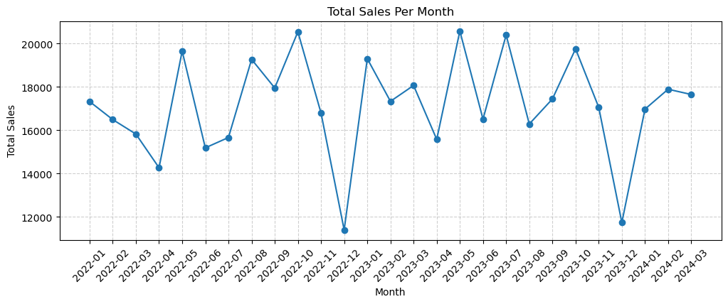

```python
sales_per_month = data.groupby(data['Monday_date'].dt.to_period('M'))['Sales'].sum()

plt.figure(figsize=(12, 4))
plt.plot(sales_per_month.index.astype(str), sales_per_month.values, marker='o')

# Formatting the plot
plt.xlabel('Month')
plt.ylabel('Total Sales')
plt.title('Total Sales Per Month')
plt.xticks(rotation=45)
plt.grid(True, linestyle='--', alpha=0.6)
```

We do not see any clear trend (this is, the mean of the values going up or down through time) but we can see some indicators of seasonality, like a drop in sales each december (a posible reason could be that the store is closed in holidays).

**Predictors through time**:

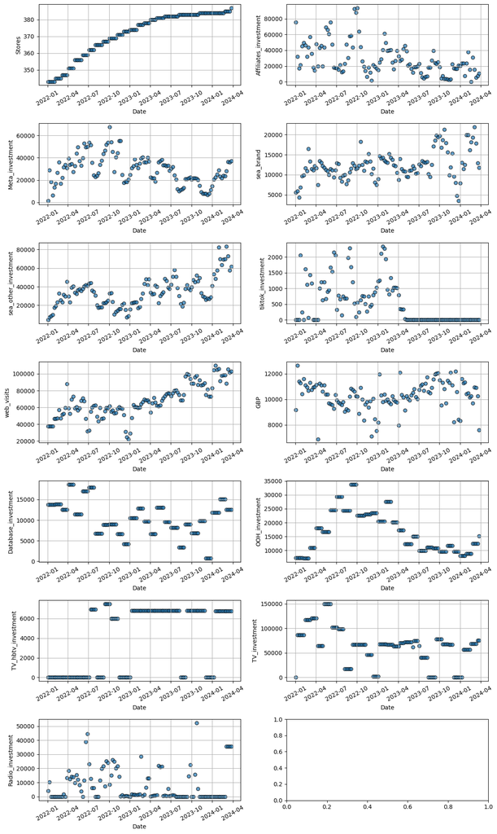

```python
# List that has all the columns except 'Monday_date' and 'Sales'
predictors_wo_date = [item for item in columns if item not in ['Monday_date', 'Sales']]

fig, axes = plt.subplots(7, 2, figsize=(12, 20))
axes = axes.ravel()

for i, col in enumerate(predictors_wo_date):
    ax = axes[i]
    ax.scatter(data['Monday_date'], data[col], alpha=0.7, edgecolor='k')
    ax.xaxis.set_tick_params(rotation=30)
    ax.set_xlabel('Date')
    ax.set_ylabel(col)

    ax.grid(True)

plt.tight_layout()
```

### Distribution of the variables

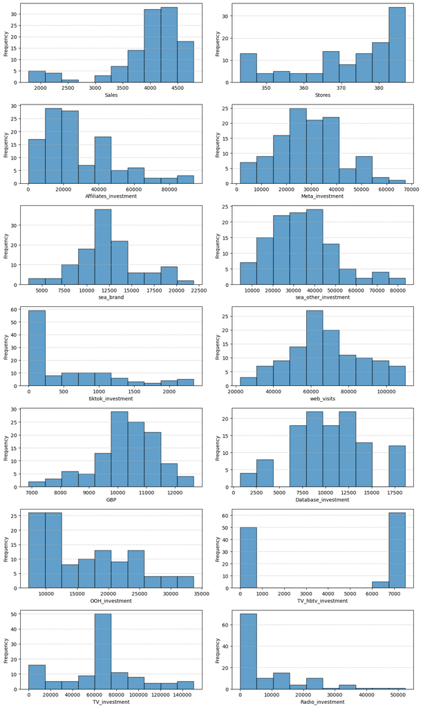

```python
# List that has all the columns except 'Monday_date'
columns_wo_date = [item for item in columns if item not in ['Monday_date']]

fig, axes = plt.subplots(7, 2, figsize=(12, 20))
axes = axes.ravel()

for i, col in enumerate(columns_wo_date):
    ax = axes[i]
    ax.hist(data[col], bins=10, edgecolor='k', alpha=0.7)
    ax.set_xlabel(col)
    ax.set_ylabel('Frequency')
    ax.grid(axis='y', linestyle='--', alpha=0.7)

plt.tight_layout()
```

### Relation between response and predictors

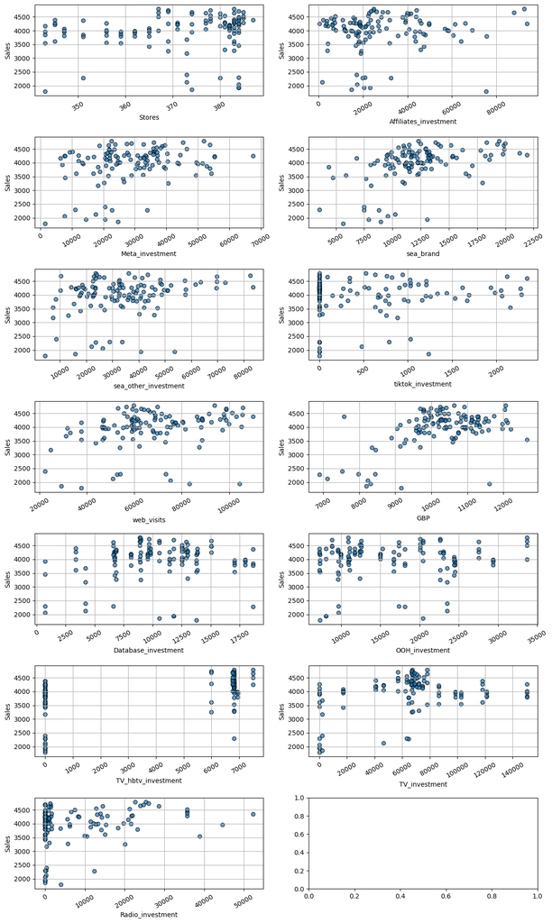

```python
fig, axes = plt.subplots(7, 2, figsize=(12, 20))
axes = axes.ravel()

for i, col in enumerate(predictors_wo_date):
    ax = axes[i]
    ax.scatter(data[col], data['Sales'], alpha=0.7, edgecolor='k')
    ax.xaxis.set_tick_params(rotation=30)
    ax.set_xlabel(col)
    ax.set_ylabel('Sales')

    ax.grid(True)

plt.tight_layout()
```

### Interaction between variables

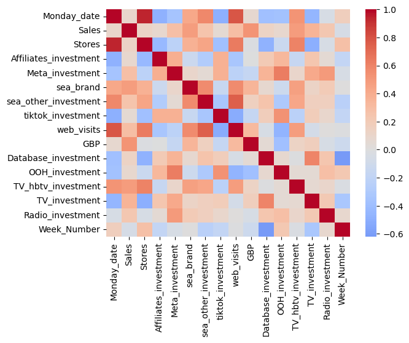

```python
sns.heatmap(data.corr(), cmap='coolwarm', center=0)
```

```python
predictors_wo_date_df = data[predictors_wo_date]
predictors_wo_date_df = sm.add_constant(predictors_wo_date_df)

vif_data = pd.DataFrame()
vif_data['Feature'] = predictors_wo_date_df.columns
vif_data['VIF'] = [variance_inflation_factor(predictors_wo_date_df.values, i) for i in range(predictors_wo_date_df.shape[1])]

print(vif_data)
```

```
                  Feature          VIF
0                   const  5482.113717
1                  Stores     6.702042
2   Affiliates_investment     1.542524
3         Meta_investment     2.917768
4               sea_brand     1.981573
5    sea_other_investment     3.688442
6       tiktok_investment     1.778041
7              web_visits     4.632176
8                     GBP     1.541367
9     Database_investment     2.389319
10         OOH_investment     3.071952
11     TV_hbtv_investment     2.715335
12          TV_investment     2.680426
13       Radio_investment     1.432933
```

The only highly-correlated feature seem to be stores, as it reflects the date (more stores opened with the pass of the time).

## Preprocessing

### Add month and year columns

```python
full_dataset['Year'] = full_dataset['Monday_date'].dt.year
full_dataset['Month'] = full_dataset['Monday_date'].dt.month
```

### Date variable: OHE with LOO

For our `Monday_date` variable, we are going to apply One Hot Enconding with Leave-One-Out regularization.

```python
full_dataset['Week_Number'] = full_dataset['Monday_date'].dt.isocalendar().week
```

```python
def calculate_sales_in_week(row):

    week_sales = full_dataset[full_dataset['Week_Number'] == row['Week_Number']]['Sales']
    week_sales = week_sales[week_sales.index != row.name]  # Exclude the current row
    return week_sales.mean()

full_dataset['Week_Sales'] = full_dataset.apply(calculate_sales_in_week, axis=1)
```

For example:

```python
print(f"{full_dataset[(full_dataset['Year'] == 2022) & (full_dataset['Week_Number'] == 52)]['Week_Sales'].values} = {full_dataset[(full_dataset['Year'] == 2023) & (full_dataset['Week_Number'] == 52)]['Sales'].values}")

print(f"{full_dataset[(full_dataset['Year'] == 2022) & (full_dataset['Week_Number'] == 1)]['Sales'].values} + {full_dataset[(full_dataset['Year'] == 2023) & (full_dataset['Week_Number'] == 1)]['Sales'].values} / 2 = {full_dataset[(full_dataset['Year'] == 2024) & (full_dataset['Week_Number'] == 1)]['Week_Sales'].values}")
```

```
[2303.] = [2303.]
[1784.] + [1861.] / 2 = [1822.5]
```

As the test part of the full dataset does not have response, there is no data leakeage. Now, we can split again into `data` and `prediction_data`:

```python
data = full_dataset[full_dataset['Sales'].notna()]
prediction_data = full_dataset[full_dataset['Sales'].isna()].drop(columns=['Sales'])
```

```python
data.head()
```

|  | Monday_date | Sales | Stores | Affiliates_investment | Meta_investment | sea_brand | sea_other_investment | tiktok_investment | web_visits | GBP | Database_investment | OOH_investment | TV_hbtv_investment | TV_investment | Radio_investment | Year | Month | Week_Number | Week_Sales |
| --- | --- | --- | --- | --- | --- | --- | --- | --- | --- | --- | --- | --- | --- | --- | --- | --- | --- | --- | --- |
| 0 | 2022-01-03 | 1784.0 | 343 | 75438.0 | 1507.73 | 5612.98 | 4277.98 | 0.00 | 37616 | 9158 | 13765.0 | 7276.096 | 0.0 | 0.000 | 3990.534594 | 2022 | 1 | 1 | 1897.5 |
| 1 | 2022-01-10 | 3550.0 | 343 | 31834.0 | 28946.82 | 5889.35 | 7276.61 | 0.00 | 37616 | 12656 | 13765.0 | 7276.096 | 0.0 | 86647.328 | 10451.400127 | 2022 | 1 | 2 | 2939.0 |
| 2 | 2022-01-17 | 3849.0 | 343 | 16898.0 | 18356.52 | 4363.21 | 8329.27 | 0.00 | 37616 | 11402 | 13765.0 | 7276.096 | 0.0 | 86647.328 | 0.000000 | 2022 | 1 | 3 | 4525.5 |
| 3 | 2022-01-24 | 4172.0 | 343 | 21278.0 | 6320.86 | 6813.07 | 10015.02 | 2053.84 | 37616 | 11280 | 13765.0 | 7276.096 | 0.0 | 86647.328 | 0.000000 | 2022 | 1 | 4 | 4311.5 |
| 4 | 2022-01-31 | 3971.0 | 343 | 45546.0 | 13617.16 | 9635.79 | 17285.06 | 250.37 | 46616 | 10415 | 13765.0 | 7276.096 | 0.0 | 86647.328 | 0.000000 | 2022 | 1 | 5 | 4467.0 |

```python
columns = list(data.columns)
print(columns)
```

[output not shown]

Let's check now the relationship between this new column (`Week_Sales`) and the `Sales` response with a quick linear regression model:

```
R^2 = 0.52
```

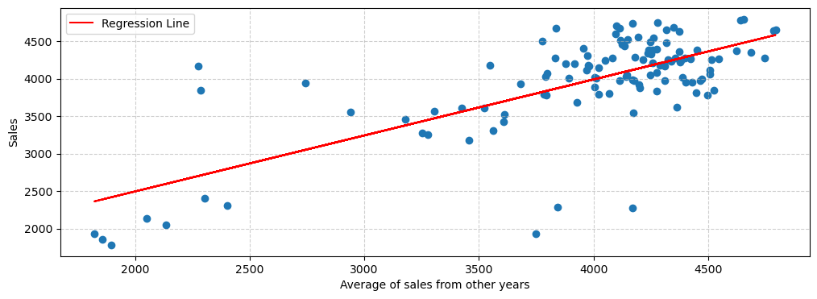

```python
x = data['Week_Sales'].values.reshape(-1, 1)
y = data['Sales'].values

model = LinearRegression()
model.fit(x, y)
y_pred = model.predict(x)

plt.figure(figsize=(12,4))
plt.scatter(x, y)
plt.plot(x, y_pred, label='Regression Line', color='r')
plt.xlabel('Average of sales from other years')
plt.ylabel('Sales')
plt.legend()
plt.grid(True, linestyle='--', alpha=0.6)

r2 = r2_score(y, y_pred)
print(f"R^2 = {r2:.2f}")
```

There is a correlation between them, so the new feature that we have created `Week_Sales` will probably help when training the models. This has been achieved without any data leakage from the test dataset nor the response for each instance. It is just a stat that reflects the sales for that week from another years, something that a business can easily calculate.

## Dataset insights

In this section, now that we have preprocessed the dataset and before starting developing the models, we are going to give some final important insights relating the dataset features.

```python
X = data.drop(columns=['Sales', 'Monday_date'])
y = data['Sales']
```

### Correlation

Let's focus now on the correlation between features now that we have a new variable `Week_Sales`:

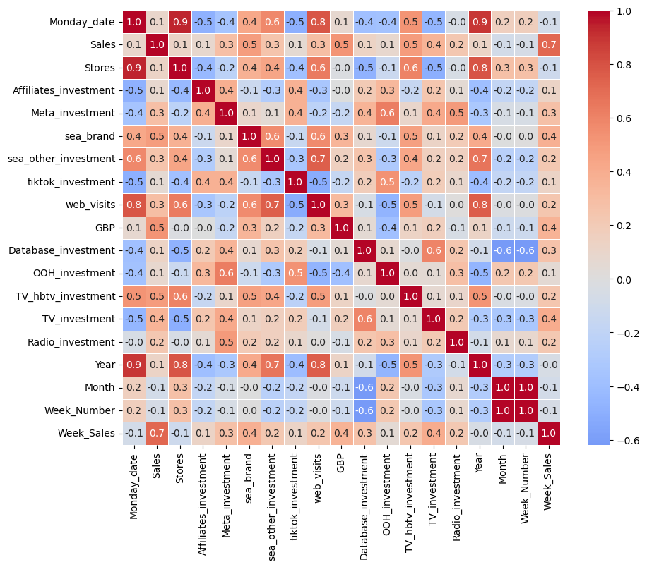

```python
plt.figure(figsize=(10, 8))
sns.heatmap(data.corr(), cmap='coolwarm', center=0, linewidths=0.5, annot=True, fmt=".1f")
```

Key aspects of the correlations between features:

A simple correlation analysis can show us how the different inversions in investments are helping with sales, with the most valuable being the ones related to TV (classic TV and hybrid TV). Investment in some online platforms like Meta (Facebook) or search engine advertising (SEA) are also correlated. Then, we have the rest of the investments, that show a low but non-zero correlation. This simple tool could be very useful for knowing how to invest in the future for the business.

#### F-Test (ANOVA) and Mutual Info Regression

Now, we are going to run two more complex tests for determining the relationship between `Sales` and the rest of the investment features. They will be an **F-test** based on an ANOVA (Analysis of Variance) model and, to capture non-linear relationships, we will also estimate the mutual information between them.

```python
f_scores, p_values = f_regression(X, y)
mutual_info_scores = mutual_info_regression(X, y, random_state=0)

info_tests = pd.DataFrame({
    'Feature': X.columns,
    'F-Statistic': f_scores,
    'P-Value': p_values,
    'Mutual Information': mutual_info_scores
})

# Format
info_tests['F-Statistic'] = info_tests['F-Statistic'].round(3)
info_tests['P-Value'] = info_tests['P-Value'].apply(lambda x: f"{x:.2e}")
info_tests['Mutual Information'] = info_tests['Mutual Information'].round(3)
```

**Ordering by F-Statistic**:

```python
info_tests.sort_values(by='F-Statistic', ascending=False)
```

|  | Feature | F-Statistic | P-Value | Mutual Information |
| --- | --- | --- | --- | --- |
| 16 | Week_Sales | 125.021 | 4.31e-20 | 0.424 |
| 7 | GBP | 44.601 | 8.99e-10 | 0.306 |
| 10 | TV_hbtv_investment | 35.441 | 2.92e-08 | 0.188 |
| 3 | sea_brand | 34.149 | 4.85e-08 | 0.119 |
| 11 | TV_investment | 16.569 | 8.64e-05 | 0.337 |
| 6 | web_visits | 10.775 | 1.36e-03 | 0.192 |
| 2 | Meta_investment | 10.557 | 1.52e-03 | 0.018 |
| 4 | sea_other_investment | 8.228 | 4.91e-03 | 0.021 |
| 12 | Radio_investment | 6.441 | 1.25e-02 | 0.029 |
| 8 | Database_investment | 2.049 | 1.55e-01 | 0.125 |
| 13 | Year | 1.789 | 1.84e-01 | 0.087 |
| 0 | Stores | 1.717 | 1.93e-01 | 0.184 |
| 9 | OOH_investment | 0.873 | 3.52e-01 | 0.050 |
| 14 | Month | 0.790 | 3.76e-01 | 0.222 |
| 1 | Affiliates_investment | 0.683 | 4.10e-01 | 0.088 |
| 5 | tiktok_investment | 0.465 | 4.97e-01 | 0.022 |
| 15 | Week_Number | 0.391 | 5.33e-01 | 0.250 |

**Ordering by Mutual Information**:

```python
info_tests.sort_values(by='Mutual Information', ascending=False)
```

|  | Feature | F-Statistic | P-Value | Mutual Information |
| --- | --- | --- | --- | --- |
| 16 | Week_Sales | 125.021 | 4.31e-20 | 0.424 |
| 11 | TV_investment | 16.569 | 8.64e-05 | 0.337 |
| 7 | GBP | 44.601 | 8.99e-10 | 0.306 |
| 15 | Week_Number | 0.391 | 5.33e-01 | 0.250 |
| 14 | Month | 0.790 | 3.76e-01 | 0.222 |
| 6 | web_visits | 10.775 | 1.36e-03 | 0.192 |
| 10 | TV_hbtv_investment | 35.441 | 2.92e-08 | 0.188 |
| 0 | Stores | 1.717 | 1.93e-01 | 0.184 |
| 8 | Database_investment | 2.049 | 1.55e-01 | 0.125 |
| 3 | sea_brand | 34.149 | 4.85e-08 | 0.119 |
| 1 | Affiliates_investment | 0.683 | 4.10e-01 | 0.088 |
| 13 | Year | 1.789 | 1.84e-01 | 0.087 |
| 9 | OOH_investment | 0.873 | 3.52e-01 | 0.050 |
| 12 | Radio_investment | 6.441 | 1.25e-02 | 0.029 |
| 5 | tiktok_investment | 0.465 | 4.97e-01 | 0.022 |
| 4 | sea_other_investment | 8.228 | 4.91e-03 | 0.021 |
| 2 | Meta_investment | 10.557 | 1.52e-03 | 0.018 |

This test takes into account non-linearity and it is showing a similar order of importance except for some features, like `Database_investment`, that are more relevant here. During the development and training of our models, we will study more the predictive value of the features, focusing on the investment, to see if we can get more useful information. However, these analysis helped us understand how the response `Sales` is related to the investment features and which investments the business should focus on.

## Evaluation Method

For comparing each of the models that we are going to try and for hyper-parameter optimization, we are going to follow this steps:

1. Holdout (outer evaluation): Split `data` into train and test with 80-20%.
2. Cross-Validation (inner evaluation): For each model, tune the HPs (HPO) with 10-fold CV using Optuna. Store MAE, params and time elapsed.
3. Compare models using MAE.
4. Select the best model and use it with the test data (not the prediction data) for performance evaluation.
5. Final model: do HPO for that model using all the data.

Select the final predictors:

```python
data.columns
```

```
Index(['Monday_date', 'Sales', 'Stores', 'Affiliates_investment',
       'Meta_investment', 'sea_brand', 'sea_other_investment',
       'tiktok_investment', 'web_visits', 'GBP', 'Database_investment',
       'OOH_investment', 'TV_hbtv_investment', 'TV_investment',
       'Radio_investment', 'Year', 'Month', 'Week_Number', 'Week_Sales'],
      dtype='object')
```

```python
# Keep stores out as it does not show any predictive value
predictors = [item for item in columns if item not in ['Monday_date', 'Sales', 'Stores', 'Year', 'Month', 'Week_Number']]
print(predictors)
```

```
['Affiliates_investment', 'Meta_investment', 'sea_brand', 'sea_other_investment', 'tiktok_investment', 'web_visits', 'GBP', 'Database_investment', 'OOH_investment', 'TV_hbtv_investment', 'TV_investment', 'Radio_investment', 'Week_Sales']
```

```python
X = data[predictors]
y = data['Sales']

X_train, X_test, y_train, y_test = train_test_split(X, y, test_size=0.2, random_state=RANDOM_SEED)
```

```python
# Inner evaluation
k = 10
inner = KFold(n_splits=k, shuffle=True, random_state=RANDOM_SEED)
```

```python
# Store metrics
du_metrics = {}
lr_metrics = {}
fi_metrics = {}
pc_metrics = {}
rd_metrics = {}
ls_metrics = {}
en_metrics = {}
dt_metrics = {}
rf_metrics = {}
et_metrics = {}
gb_metrics = {}
xg_metrics = {}
nn_metrics = {}
```

This steps will allow us to train our model without any risk of overfitting or data leakeage.

## Models

Now that we have defined all the steps and we have our data ready, we are going to introduce several models to predict the `Sales` variable. We are going to train models in order of complexity, as simpler models are more interpretable, giving us more insights into our data, while more complex models have a higher predicting power (while being less interpretable).

### Dummy model

The first model will be a dummy model, as this will set the "worst" MAE possible so we can compare the rest of the models to it. As the objective is to minimize the MAE, the strategy will be set to `'median'`, which minimizes it.

```python
du_regressor = DummyRegressor(strategy='median')  # Median because we are using MAE

start_time = time.time()

du_metrics['Method'] = 'Dummy Model'
du_metrics['MAE'] = -cross_val_score(du_regressor, X_train, y_train, cv=inner, scoring='neg_mean_absolute_error').mean()
du_metrics['Params'] = None
du_metrics['Time'] = time.time() - start_time

print("Best MAE:", du_metrics['MAE'])
print("Best Parameters:", du_metrics['Params'])
print(f"Time elapsed: {du_metrics['Time']:.2f} s")
```

```
Best MAE: 461.81000000000006
Best Parameters: None
Time elapsed: 0.01 s
```

Now, we can introduce the models comparing it to this "worst" value.

### Linear Regression

The first model that we are going to introduce is a Linear Regressor. We will introduce it first in sklearn for comparing with the rest of the models, but we will also use the `stats_models` library, as it gives us relevant information about our variables.

#### sklearn

```python
lr_regressor = LinearRegression()

start_time = time.time()

lr_metrics['Method'] = 'Linear Regression'
lr_metrics['MAE'] = -cross_val_score(lr_regressor, X_train, y_train, cv=inner, scoring='neg_mean_absolute_error').mean()
lr_metrics['Params'] = None
lr_metrics['Time'] = time.time() - start_time

print("Best MAE:", lr_metrics['MAE'])
print("Best Parameters:", lr_metrics['Params'])
print(f"Time elapsed: {lr_metrics['Time']:.2f} s")
```

```
Best MAE: 288.6708716635145
Best Parameters: None
Time elapsed: 0.02 s
```

As we know, for Linear Regression a previous scaling is not needed, as we can see here:

```python
lr_regressor = Pipeline([
    ('scaler', StandardScaler()),
    ('regressor', LinearRegression())
])

start_time = time.time()

print("Best MAE:", -cross_val_score(lr_regressor, X_train, y_train, cv=inner, scoring='neg_mean_absolute_error').mean())
print("Best Parameters:", None)
print(f"Time elapsed: {(time.time() - start_time):.2f} s")
```

```
Best MAE: 288.6708716635143
Best Parameters: None
Time elapsed: 0.03 s
```

#### sm

With `sm` library:

```python
X_train_c = sm.add_constant(X_train)
```

```python
lr_model = sm.OLS(y_train, X_train_c).fit()
print(lr_model.summary())
```

```
                            OLS Regression Results
==============================================================================
Dep. Variable:                  Sales   R-squared:                       0.746
Model:                            OLS   Adj. R-squared:                  0.704
Method:                 Least Squares   F-statistic:                     17.86
Date:                Sat, 18 Jan 2025   Prob (F-statistic):           2.05e-18
Time:                        17:52:03   Log-Likelihood:                -675.42
No. Observations:                  93   AIC:                             1379.
Df Residuals:                      79   BIC:                             1414.
Df Model:                          13
Covariance Type:            nonrobust
=========================================================================================
                            coef    std err          t      P>|t|      [0.025      0.975]
-----------------------------------------------------------------------------------------
const                  -620.6402    480.537     -1.292      0.200   -1577.125     335.845
Affiliates_investment    -0.0011      0.002     -0.493      0.623      -0.006       0.003
Meta_investment           0.0046      0.005      0.864      0.390      -0.006       0.015
sea_brand                 0.0095      0.015      0.631      0.530      -0.021       0.040
sea_other_investment      0.0024      0.005      0.469      0.641      -0.008       0.013
tiktok_investment         0.0637      0.085      0.753      0.454      -0.105       0.232
web_visits               -0.0023      0.005     -0.507      0.614      -0.011       0.007
GBP                       0.1985      0.045      4.409      0.000       0.109       0.288
Database_investment      -0.0275      0.013     -2.142      0.035      -0.053      -0.002
OOH_investment            0.0049      0.009      0.531      0.597      -0.014       0.024
TV_hbtv_investment        0.0583      0.015      3.905      0.000       0.029       0.088
TV_investment             0.0010      0.002      0.598      0.551      -0.002       0.004
Radio_investment          0.0054      0.005      1.146      0.255      -0.004       0.015
Week_Sales                0.5585      0.087      6.403      0.000       0.385       0.732
==============================================================================
Omnibus:                       45.474   Durbin-Watson:                   1.961
Prob(Omnibus):                  0.000   Jarque-Bera (JB):              186.010
Skew:                          -1.519   Prob(JB):                     4.06e-41
Kurtosis:                       9.226   Cond. No.                     1.42e+06
==============================================================================

Notes:
[1] Standard Errors assume that the covariance matrix of the errors is correctly specified.
[2] The condition number is large, 1.42e+06. This might indicate that there are
strong multicollinearity or other numerical problems.
```

*Note: as we saw in the first assignment, the two notes that appear in the model are not relevant for the results*

The results from the model are similar to those we obtained in the previous section.

**Significant predictors** ($p<0.05$):

1. **GBP**:
   - $p < 0.001$
   - Interpretation: as GBP is probably related to some expenditure, this means that expending more leads to more sales. One-unit increase in `GBP` -> 0.1985 increase in `Sales`.
2. **TV_hbtv_investment**:
   - p-value: < 0.001
   - Interpretation: As we saw, this was the most linearly correlated investment variable. One-unit increase in `TV_hbtv_investment` -> 0.0583 increase in `Sales`.
3. **Week_Sales**:
   - p-value: < 0.001
   - Interpretation: This was the variable introduced in the preprocessing step, which is very linearly correlated to the response. This shows how seasonality is very relevant to predicting sales. One-unit increase in `Week_Sales` -> 0.5585 increase in `Sales`.
4. **Database_investment**:
   - p-value: 0.035
   - Interpretation: This investment also appears to be linearly correlated to the response, although it is less relevant than the previous variables, as one-unit increase in `Database_investment` -> 0.0275 decrease in `Sales`.

Before training more advanced models, we are going to build upon linear regression to see if it can get better results.

### Linear Regression with Feature Interaction

We will add feature interaction terms to those investment variables that show a correlation $>0.5$, to see if they add predictive value to the linear regression model:

```python
# Columns that end with '_investment'
investment_columns = [col for col in data.columns if col.endswith('_investment')]
investment_data = data[investment_columns]
investment_data.head()
```

|  | Affiliates_investment | Meta_investment | sea_other_investment | tiktok_investment | Database_investment | OOH_investment | TV_hbtv_investment | TV_investment | Radio_investment |
| --- | --- | --- | --- | --- | --- | --- | --- | --- | --- |
| 0 | 75438.0 | 1507.73 | 4277.98 | 0.00 | 13765.0 | 7276.096 | 0.0 | 0.000 | 3990.534594 |
| 1 | 31834.0 | 28946.82 | 7276.61 | 0.00 | 13765.0 | 7276.096 | 0.0 | 86647.328 | 10451.400127 |
| 2 | 16898.0 | 18356.52 | 8329.27 | 0.00 | 13765.0 | 7276.096 | 0.0 | 86647.328 | 0.000000 |
| 3 | 21278.0 | 6320.86 | 10015.02 | 2053.84 | 13765.0 | 7276.096 | 0.0 | 86647.328 | 0.000000 |
| 4 | 45546.0 | 13617.16 | 17285.06 | 250.37 | 13765.0 | 7276.096 | 0.0 | 86647.328 | 0.000000 |

```python
# Correlation matrix
correlation_matrix = investment_data.corr()

# Find highly correlated features
threshold = 0.5  # threshold
high_correlation_pairs = [
    (col1, col2)
    for col1, col2 in combinations(investment_columns, 2)
    if abs(correlation_matrix.loc[col1, col2]) > threshold
]

# Create interaction terms
interactions = pd.DataFrame(index=data.index)
for col1, col2 in high_correlation_pairs:
    interactions[f"{col1}:{col2}"] = data[col1] * data[col2]

# Add interaction terms
data_with_interactions = pd.concat([data, interactions], axis=1)
data_with_interactions.head()
```

|  | Monday_date | Sales | Stores | Affiliates_investment | Meta_investment | sea_brand | sea_other_investment | tiktok_investment | web_visits | GBP | Database_investment | OOH_investment | TV_hbtv_investment | TV_investment | Radio_investment | Year | Month | Week_Number | Week_Sales | Meta_investment:OOH_investment | tiktok_investment:OOH_investment | Database_investment:TV_investment |
| --- | --- | --- | --- | --- | --- | --- | --- | --- | --- | --- | --- | --- | --- | --- | --- | --- | --- | --- | --- | --- | --- | --- |
| 0 | 2022-01-03 | 1784.0 | 343 | 75438.0 | 1507.73 | 5612.98 | 4277.98 | 0.00 | 37616 | 9158 | 13765.0 | 7276.096 | 0.0 | 0.000 | 3990.534594 | 2022 | 1 | 1 | 1897.5 | 1.097039e+07 | 0.000000e+00 | 0.000000e+00 |
| 1 | 2022-01-10 | 3550.0 | 343 | 31834.0 | 28946.82 | 5889.35 | 7276.61 | 0.00 | 37616 | 12656 | 13765.0 | 7276.096 | 0.0 | 86647.328 | 10451.400127 | 2022 | 1 | 2 | 2939.0 | 2.106198e+08 | 0.000000e+00 | 1.192700e+09 |
| 2 | 2022-01-17 | 3849.0 | 343 | 16898.0 | 18356.52 | 4363.21 | 8329.27 | 0.00 | 37616 | 11402 | 13765.0 | 7276.096 | 0.0 | 86647.328 | 0.000000 | 2022 | 1 | 3 | 4525.5 | 1.335638e+08 | 0.000000e+00 | 1.192700e+09 |
| 3 | 2022-01-24 | 4172.0 | 343 | 21278.0 | 6320.86 | 6813.07 | 10015.02 | 2053.84 | 37616 | 11280 | 13765.0 | 7276.096 | 0.0 | 86647.328 | 0.000000 | 2022 | 1 | 4 | 4311.5 | 4.599118e+07 | 1.494394e+07 | 1.192700e+09 |
| 4 | 2022-01-31 | 3971.0 | 343 | 45546.0 | 13617.16 | 9635.79 | 17285.06 | 250.37 | 46616 | 10415 | 13765.0 | 7276.096 | 0.0 | 86647.328 | 0.000000 | 2022 | 1 | 5 | 4467.0 | 9.907976e+07 | 1.821716e+06 | 1.192700e+09 |

```python
# Add predictors with interaction
high_correlation_list = []
for col1, col2 in high_correlation_pairs:
    high_correlation_list.append(f"{col1}:{col2}")

print(f"Interaction terms added: {high_correlation_list}")
predictors_int = predictors + high_correlation_list
```

```
Interaction terms added: ['Meta_investment:OOH_investment', 'tiktok_investment:OOH_investment', 'Database_investment:TV_investment']
```

```python
X_int = data_with_interactions[predictors_int]

X_train_int, X_test_int, y_train, y_test = train_test_split(X_int, y, test_size=0.2, random_state=RANDOM_SEED)
```

#### sklearn

```python
lr_regressor = LinearRegression()

start_time = time.time()

fi_metrics['Method'] = 'Linear Regression with Feature Interaction'
fi_metrics['MAE'] = -cross_val_score(lr_regressor, X_train_int, y_train, cv=inner, scoring='neg_mean_absolute_error').mean()
fi_metrics['Params'] = None
fi_metrics['Time'] = time.time() - start_time

print("Best MAE:", fi_metrics['MAE'])
print("Best Parameters:", fi_metrics['Params'])
print(f"Time elapsed: {fi_metrics['Time']:.2f} s")
```

```
Best MAE: 290.4107896925567
Best Parameters: None
Time elapsed: 0.01 s
```

MAE did not go down, so it seems that the new interaction terms did not give predictive value. Let's inspect it with `sm`.

#### sm

```python
X_train_int_c = sm.add_constant(X_train_int)
```

```python
fi_model = sm.OLS(y_train, X_train_int_c).fit()
print(fi_model.summary())
```

```
                            OLS Regression Results
==============================================================================
Dep. Variable:                  Sales   R-squared:                       0.766
Model:                            OLS   Adj. R-squared:                  0.716
Method:                 Least Squares   F-statistic:                     15.53
Date:                Sat, 18 Jan 2025   Prob (F-statistic):           8.27e-18
Time:                        17:52:03   Log-Likelihood:                -671.68
No. Observations:                  93   AIC:                             1377.
Df Residuals:                      76   BIC:                             1420.
Df Model:                          16
Covariance Type:            nonrobust
=====================================================================================================
                                        coef    std err          t      P>|t|      [0.025      0.975]
-----------------------------------------------------------------------------------------------------
const                              -742.0568    615.027     -1.207      0.231   -1966.990     482.876
Affiliates_investment                 0.0005      0.002      0.210      0.834      -0.004       0.005
Meta_investment                       0.0207      0.011      1.880      0.064      -0.001       0.043
sea_brand                             0.0211      0.016      1.343      0.183      -0.010       0.052
sea_other_investment                 -0.0003      0.005     -0.058      0.954      -0.011       0.010
tiktok_investment                     0.0523      0.242      0.216      0.829      -0.429       0.534
web_visits                           -0.0022      0.005     -0.487      0.628      -0.011       0.007
GBP                                   0.2063      0.046      4.487      0.000       0.115       0.298
Database_investment                  -0.0627      0.020     -3.061      0.003      -0.103      -0.022
OOH_investment                        0.0280      0.020      1.406      0.164      -0.012       0.068
TV_hbtv_investment                    0.0745      0.017      4.495      0.000       0.041       0.108
TV_investment                        -0.0075      0.004     -1.881      0.064      -0.016       0.000
Radio_investment                      0.0061      0.005      1.320      0.191      -0.003       0.015
Week_Sales                            0.5213      0.087      5.966      0.000       0.347       0.695
Meta_investment:OOH_investment    -8.006e-07   5.31e-07     -1.508      0.136   -1.86e-06    2.57e-07
tiktok_investment:OOH_investment  -1.777e-06   1.11e-05     -0.160      0.873   -2.39e-05    2.04e-05
Database_investment:TV_investment  7.209e-07   3.26e-07      2.208      0.030    7.08e-08    1.37e-06
==============================================================================
Omnibus:                       38.013   Durbin-Watson:                   1.978
Prob(Omnibus):                  0.000   Jarque-Bera (JB):              123.150
Skew:                          -1.323   Prob(JB):                     1.81e-27
Kurtosis:                       7.978   Cond. No.                     1.76e+10
==============================================================================

Notes:
[1] Standard Errors assume that the covariance matrix of the errors is correctly specified.
[2] The condition number is large, 1.76e+10. This might indicate that there are
strong multicollinearity or other numerical problems.
```

Only one interaction term seem to be significantly impact the sales: **Database_investment:TV_investment**. However, its coefficient is very small, so interaction between features does not seem to very relevant in our problem (as the VIF indicated) or this interaction terms are too simple for reflecting it. However, more complex models like the ones that we are going to present may reflect some degree of interaction between variables and help us with prediction.

### Linear Regression with PCA

As adding feature interaction did not work and many of the predictors do not seem to be very relevant, we are going to check if linear regression gets better with dimensionality reduction. For it, we will introduce PCA into a pipeline and optimize the number of components to select:

```python
def objective(trial):

    n_components = trial.suggest_int("n_components", 1, min(X_train.shape[1], X_train.shape[0] - 1))

    pc_regressor = Pipeline([
        ('scaler', StandardScaler()),
        ('pca', PCA(n_components=n_components)),
        ('ridge', Ridge(random_state=RANDOM_SEED))
    ])

    inner_score = cross_val_score(pc_regressor, X_train, y_train, cv=inner, scoring='neg_mean_absolute_error').mean()
    mean_mae = - inner_score

    return mean_mae

study = optuna.create_study(direction='minimize', sampler=optuna.samplers.TPESampler(seed=RANDOM_SEED))
start_time = time.time()
study.optimize(objective, n_trials=20)

pc_metrics['Method'] = 'Linear Regression with PCA'
pc_metrics['MAE'] = study.best_value
pc_metrics['Params'] = study.best_params
pc_metrics['Time'] = time.time() - start_time

print("Best MAE:", pc_metrics['MAE'])
print("Best Parameters:", pc_metrics['Params'])
print(f"Time elapsed: {pc_metrics['Time']:.2f} s")
```

```
Best MAE: 277.60612645454535
Best Parameters: {'n_components': 9}
Time elapsed: 0.39 s
```

PCA seems to help a bit in the linear regression, probably because, as we said, many features are not relevant, but the difference is not significant.

### Ridge Regression

Now we will introduce Ridge and Lasso regression, linear regression models with regularization techniches. In Ridge regression, the penalty of the loss function is proportional to the square of the coefficients.

```python
def objective(trial):

    params = {
        "alpha": trial.suggest_float("alpha", 1e-6, 1e6, log=True)
    }

    rd_regressor = Pipeline([
        ('scaler', StandardScaler()),
        ('ridge', Ridge(random_state=RANDOM_SEED, **params))
    ])

    inner_score = cross_val_score(rd_regressor, X_train, y_train, cv=inner, scoring='neg_mean_absolute_error').mean()
    mean_mae = - inner_score

    return mean_mae

study = optuna.create_study(direction='minimize', sampler=optuna.samplers.TPESampler(seed=RANDOM_SEED))
start_time = time.time()
study.optimize(objective, n_trials=500)

rd_metrics['Method'] = 'Ridge Regression'
rd_metrics['MAE'] = study.best_value
rd_metrics['Params'] = study.best_params
rd_metrics['Time'] = time.time() - start_time

print("Best MAE:", rd_metrics['MAE'])
print("Best Parameters:", rd_metrics['Params'])
print(f"Time elapsed: {rd_metrics['Time']:.2f} s")
```

```
Best MAE: 280.62918355983567
Best Parameters: {'alpha': 10.587024039251805}
Time elapsed: 7.72 s
```

MAE went a bit down, showing that regularization is probably better, but the difference is not significant.

### Lasso Regression

In Lasso regression, the penalty is proportional to the absolute value of the coefficients:

```python
def objective(trial):

    params = {
        "alpha": trial.suggest_float("alpha", 1e-6, 1e6, log=True)
    }

    ls_regressor = Pipeline([
        ('scaler', StandardScaler()),
        ('ridge', Lasso(random_state=RANDOM_SEED, **params))
    ])

    inner_score = cross_val_score(ls_regressor, X_train, y_train, cv=inner, scoring='neg_mean_absolute_error').mean()
    mean_mae = - inner_score

    return mean_mae

study = optuna.create_study(direction='minimize', sampler=optuna.samplers.TPESampler(seed=RANDOM_SEED))
start_time = time.time()
study.optimize(objective, n_trials=500)

ls_metrics['Method'] = 'Lasso Regression'
ls_metrics['MAE'] = study.best_value
ls_metrics['Params'] = study.best_params
ls_metrics['Time'] = time.time() - start_time

print("Best MAE:", ls_metrics['MAE'])
print("Best Parameters:", ls_metrics['Params'])
print(f"Time elapsed: {ls_metrics['Time']:.2f} s")
```

```
Best MAE: 274.86402245491956
Best Parameters: {'alpha': 30.27234657293509}
Time elapsed: 8.35 s
```

The MAE for Lasso went down compared with Ridge regression, showing us that it is probably better for this data. However, we can use Elastic Net to check if there is an optimal point between Ridge and Lasso.

### Elastic Net

```python
def objective(trial):

    params = {
        "alpha": trial.suggest_float("alpha", 1e-6, 1e6, log=True),
        "l1_ratio": trial.suggest_float("l1_ratio", 0, 1)  # L1 ratio for ElasticNet (0 = Ridge, 1 = Lasso)
    }

    en_regressor = Pipeline([
        ('scaler', StandardScaler()),
        ('elastic_net', ElasticNet(random_state=RANDOM_SEED, **params))
    ])

    inner_score = cross_val_score(en_regressor, X_train, y_train, cv=inner, scoring='neg_mean_absolute_error').mean()
    mean_mae = - inner_score

    return mean_mae

study = optuna.create_study(direction='minimize', sampler=optuna.samplers.TPESampler(seed=RANDOM_SEED))
start_time = time.time()
study.optimize(objective, n_trials=100)

en_metrics['Method'] = 'ElasticNet Regression'
en_metrics['MAE'] = study.best_value
en_metrics['Params'] = study.best_params
en_metrics['Time'] = time.time() - start_time

print("Best MAE:", en_metrics['MAE'])
print("Best Parameters:", en_metrics['Params'])
print(f"Time elapsed: {en_metrics['Time']:.2f} s")
```

```
Best MAE: 278.6335739785779
Best Parameters: {'alpha': 3.4967450777410716, 'l1_ratio': 0.9728258431724425}
Time elapsed: 1.84 s
```

### Decision Tree

The first "advanced" model that we are going to test is a simple Decision Tree, which still retains some interpretation and it does not have high complexity. As always, we will optimize the most important parameters with Optuna:

```python
def objective(trial):

    params = {
        "criterion": trial.suggest_categorical("criterion", ["squared_error", "friedman_mse", "absolute_error", "poisson"]),
        "splitter": trial.suggest_categorical("splitter", ["best", "random"]),
        "max_depth": trial.suggest_int("max_depth", 2, 20),
        "min_samples_split": trial.suggest_int("min_samples_split", 2, 20),
        "min_samples_leaf": trial.suggest_int("min_samples_leaf", 1, 20),
        "max_features": trial.suggest_categorical("max_features", [None, "sqrt", "log2"]),
    }

    dt_regressor = DecisionTreeRegressor(random_state=RANDOM_SEED, **params)

    inner_score = cross_val_score(dt_regressor, X_train, y_train, cv=inner, scoring='neg_mean_absolute_error').mean()
    mean_mae = - inner_score

    return mean_mae

study = optuna.create_study(direction='minimize', sampler=optuna.samplers.TPESampler(seed=RANDOM_SEED))
start_time = time.time()
study.optimize(objective, n_trials=100)

dt_metrics['Method'] = 'Decision Tree'
dt_metrics['MAE'] = study.best_value
dt_metrics['Params'] = study.best_params
dt_metrics['Time'] = time.time() - start_time

print("Best MAE:", dt_metrics['MAE'])
print("Best Parameters:", dt_metrics['Params'])
print(f"Time elapsed: {dt_metrics['Time']:.2f} s")
```

```
Best MAE: 308.89222222222224
Best Parameters: {'criterion': 'absolute_error', 'splitter': 'best', 'max_depth': 4, 'min_samples_split': 2, 'min_samples_leaf': 9, 'max_features': None}
Time elapsed: 1.99 s
```

It shows worse performance than linear regression models, so we will try to improve its prediction capabilities with more complex models (ensemble models) next. However, we can fit the Decision Tree with the best parameters obtained to the train data to see how the tree looks, to get some insights about it.

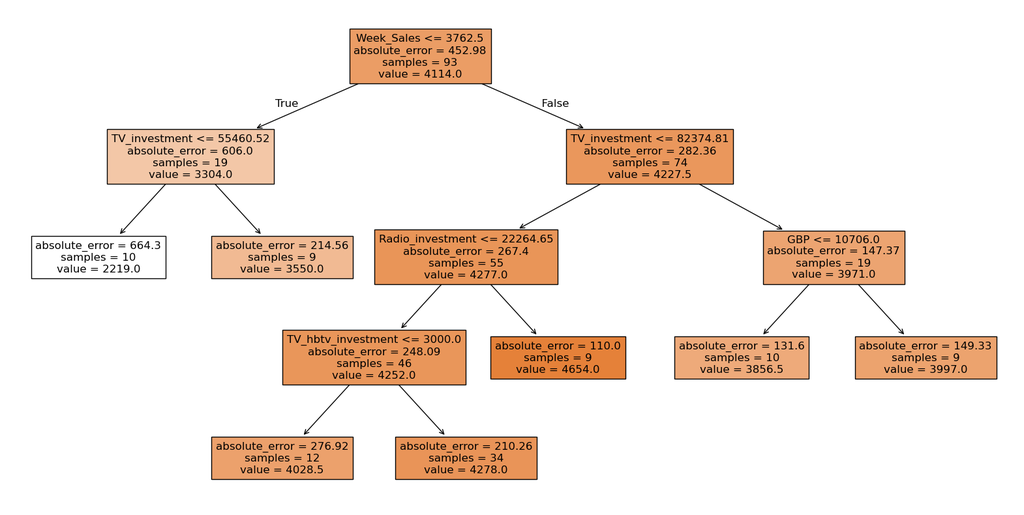

```python
dt_regressor = DecisionTreeRegressor(random_state=RANDOM_SEED, **dt_metrics['Params'])
dt_regressor.fit(X_train, y_train)

plt.figure(figsize=(20, 10))
plot_tree(dt_regressor, filled=True , feature_names=X.columns, precision=2)
plt.show()
```

The criterion used for the tree is absolute error, which may be has been influenced by the score being -MAE. The predictors used in each node are the ones that we have been seeing until now: `Week_Sales`, `TV_investment`, `TV_hbtv_investment`, `Radio_investment` and `GBP`; so here they are showing its relevance for the response `Sales`.

### Random Forest

Now that we have seen the possibilities of a single Decision Tree, we are going to train some ensemble models of them. The first of them will be a Random Forest:

```python
def objective(trial):

    params = {
        "n_estimators": trial.suggest_int("n_estimators", 10, 200),
        "max_depth": trial.suggest_int("max_depth", 2, 20),
        "min_samples_split": trial.suggest_int("min_samples_split", 2, 20),
        "min_samples_leaf": trial.suggest_int("min_samples_leaf", 1, 10),
        "max_features": trial.suggest_categorical("max_features", [None, "sqrt", "log2"]),
        "bootstrap": trial.suggest_categorical("bootstrap", [True, False]),
    }

    rf_regressor = RandomForestRegressor(random_state=RANDOM_SEED, **params)

    inner_score = cross_val_score(rf_regressor, X_train, y_train, cv=inner, scoring='neg_mean_absolute_error').mean()
    mean_mae = - inner_score

    return mean_mae

study = optuna.create_study(direction='minimize', sampler=optuna.samplers.TPESampler(seed=RANDOM_SEED))
start_time = time.time()
study.optimize(objective, n_trials=100)

rf_metrics['Method'] = 'Random Forest'
rf_metrics['MAE'] = study.best_value
rf_metrics['Params'] = study.best_params
rf_metrics['Time'] = time.time() - start_time

print("Best MAE:", rf_metrics['MAE'])
print("Best Parameters:", rf_metrics['Params'])
print(f"Time elapsed: {rf_metrics['Time']:.2f} s")
```

```
Best MAE: 291.15689856150794
Best Parameters: {'n_estimators': 32, 'max_depth': 15, 'min_samples_split': 5, 'min_samples_leaf': 1, 'max_features': 'log2', 'bootstrap': False}
Time elapsed: 17.52 s
```

It has improved substantially the performance of the single Decision Tree. However, this score is still similar to those of the linear regression models.

### Extra Trees

A different bagging ensemble model is Extra Trees, so we can compare it to Random Forests:

```python
def objective(trial):

    params = {
        "n_estimators": trial.suggest_int("n_estimators", 10, 200),
        "max_depth": trial.suggest_int("max_depth", 2, 20),
        "min_samples_split": trial.suggest_int("min_samples_split", 2, 20),
        "min_samples_leaf": trial.suggest_int("min_samples_leaf", 1, 10),
        "max_features": trial.suggest_categorical("max_features", [None, "sqrt", "log2"]),
        "bootstrap": trial.suggest_categorical("bootstrap", [True, False]),
    }

    et_regressor = ExtraTreesRegressor(random_state=RANDOM_SEED, **params)

    inner_score = cross_val_score(et_regressor, X_train, y_train, cv=inner, scoring='neg_mean_absolute_error').mean()
    mean_mae = - inner_score

    return mean_mae

study = optuna.create_study(direction='minimize', sampler=optuna.samplers.TPESampler(seed=RANDOM_SEED))
start_time = time.time()
study.optimize(objective, n_trials=100)

et_metrics['Method'] = 'Extra Trees'
et_metrics['MAE'] = study.best_value
et_metrics['Params'] = study.best_params
et_metrics['Time'] = time.time() - start_time

print("Best MAE:", et_metrics['MAE'])
print("Best Parameters:", et_metrics['Params'])
print(f"Time elapsed: {et_metrics['Time']:.2f} s")
```

```
Best MAE: 269.54295788939623
Best Parameters: {'n_estimators': 73, 'max_depth': 17, 'min_samples_split': 3, 'min_samples_leaf': 1, 'max_features': None, 'bootstrap': False}
Time elapsed: 34.17 s
```

For our data, it seems that Extra Trees works better than Random Forests. Will a boosting model improve this performance even more?

### Gradient Boosting

The first boosting model that we are going to try is Gradient Boosting (from sklearn):

```python
def objective(trial):

    params = {
        "n_estimators": trial.suggest_int("n_estimators", 50, 200),
        "learning_rate": trial.suggest_float("learning_rate", 0.001, 0.2, log=True),
        "max_depth": trial.suggest_int("max_depth", 2, 20),
        "min_samples_split": trial.suggest_int("min_samples_split", 2, 20),
        "min_samples_leaf": trial.suggest_int("min_samples_leaf", 1, 10),
        "subsample": trial.suggest_float("subsample", 0.5, 1.0),
        "max_features": trial.suggest_categorical("max_features", [None, "sqrt", "log2"]),
    }

    gb_regressor = GradientBoostingRegressor(random_state=RANDOM_SEED, **params)

    inner_score = cross_val_score(gb_regressor, X_train, y_train, cv=inner, scoring='neg_mean_absolute_error').mean()
    mean_mae = - inner_score

    return mean_mae

study = optuna.create_study(direction='minimize', sampler=optuna.samplers.TPESampler(seed=RANDOM_SEED))
start_time = time.time()
study.optimize(objective, n_trials=500)

gb_metrics['Method'] = 'Gradient Boosting'
gb_metrics['MAE'] = study.best_value
gb_metrics['Params'] = study.best_params
gb_metrics['Time'] = time.time() - start_time

print("Best MAE:", gb_metrics['MAE'])
print("Best Parameters:", gb_metrics['Params'])
print(f"Time elapsed: {gb_metrics['Time']:.2f} s")
```

```
Best MAE: 263.3861369082884
Best Parameters: {'n_estimators': 132, 'learning_rate': 0.16766144321039006, 'max_depth': 5, 'min_samples_split': 5, 'min_samples_leaf': 3, 'subsample': 0.7868858421485085, 'max_features': 'sqrt'}
Time elapsed: 108.28 s
```

And we got the best results until now. By using a 10-fold cross-validation, we can be sure that this performance is not due to overfitting, so this model will generalize well to other instances.

### XGBoost

As Gradient Boosting gave very good results, let's try the most popular boosting library: `xgboost`.

```python
def objective(trial):

    params = {
        "n_estimators": trial.suggest_int("n_estimators", 50, 200),
        "learning_rate": trial.suggest_float("learning_rate", 0.001, 0.2, log=True),
        "max_depth": trial.suggest_int("max_depth", 2, 20),
        "min_child_weight": trial.suggest_int("min_child_weight", 1, 10),
        "subsample": trial.suggest_float("subsample", 0.5, 1.0),
        "colsample_bytree": trial.suggest_float("colsample_bytree", 0.25, 1.0),
        "gamma": trial.suggest_float("gamma", 1e-5, 10, log=True),
        "reg_alpha": trial.suggest_float("reg_alpha", 1e-5, 10, log=True),
        "reg_lambda": trial.suggest_float("reg_lambda", 1e-5, 10, log=True),
    }

    xg_regressor = xgb.XGBRegressor(random_state=RANDOM_SEED, **params)

    inner_score = cross_val_score(xg_regressor, X_train, y_train, cv=inner, scoring='neg_mean_absolute_error').mean()
    mean_mae = - inner_score

    return mean_mae

study = optuna.create_study(direction='minimize', sampler=optuna.samplers.TPESampler(seed=RANDOM_SEED))
start_time = time.time()
study.optimize(objective, n_trials=500)

xg_metrics['Method'] = 'XGBoost'
xg_metrics['MAE'] = study.best_value
xg_metrics['Params'] = study.best_params
xg_metrics['Time'] = time.time() - start_time

print("Best MAE:", xg_metrics['MAE'])
print("Best Parameters:", xg_metrics['Params'])
print(f"Time elapsed: {xg_metrics['Time']:.2f} s")
```

```
Best MAE: 273.40805582682293
Best Parameters: {'n_estimators': 108, 'learning_rate': 0.13590694639586867, 'max_depth': 5, 'min_child_weight': 2, 'subsample': 0.7939068094640285, 'colsample_bytree': 0.7536942574855015, 'gamma': 0.03071880486946854, 'reg_alpha': 4.899421105963733, 'reg_lambda': 0.0009124308783209137}
Time elapsed: 620.47 s
```

Although it shows good performance and the differences are not huge between models, we will keep Gradient Boosting as the best model until now.

### Neural Network: Multi-Layer Perceptron

The final model that we are going to test is the most complex until now: a multi-layer perceptron. The number of hidden layers (`l`) and the number of elements in each one of them will be optimized, together with `activation` (as we saw in the slides) and `alpha`.

```python
def objective(trial):

    l = trial.suggest_int("l", 1, 6)

    params = {
        "hidden_layer_sizes": tuple(trial.suggest_int(f"element_{i}", 2, 30) for i in range(l)),
        "activation": trial.suggest_categorical("activation", ["identity", "logistic", "tanh", "relu"]),
        #"solver": trial.suggest_categorical("solver", ["adam", "sgd"]),
        "alpha": trial.suggest_float("alpha", 1e-5, 1e-1, log=True),
        #"learning_rate": trial.suggest_categorical("learning_rate", ["constant", "invscaling", "adaptive"]),
        #"learning_rate_init": trial.suggest_float("learning_rate_init", 1e-5, 1e-1, log=True),
        #"batch_size": trial.suggest_categorical("batch_size", [32, 64, 128])
    }

    nn_regressor = Pipeline([
        ('scaler', StandardScaler()), # Scaling is important for MLPRegressor
        ('regressor', MLPRegressor(random_state=RANDOM_SEED, max_iter=20000, **params))
    ])

    inner_score = cross_val_score(nn_regressor, X_train, y_train, cv=inner, scoring='neg_mean_absolute_error').mean()
    mean_mae = - inner_score

    return mean_mae

study = optuna.create_study(direction='minimize', sampler=optuna.samplers.TPESampler(seed=RANDOM_SEED))
start_time = time.time()
study.optimize(objective, n_trials=3000)

nn_metrics['Method'] = 'Neural Network'
nn_metrics['MAE'] = study.best_value
nn_metrics['Params'] = study.best_params
nn_metrics['Time'] = time.time() - start_time

print("Best MAE:", nn_metrics['MAE'])
print("Best Parameters:", nn_metrics['Params'])
print(f"Time elapsed: {nn_metrics['Time']:.2f} s")
```

```
Best MAE: 280.56079922986873
Best Parameters: {'l': 5, 'element_0': 30, 'element_1': 29, 'element_2': 20, 'element_3': 30, 'element_4': 24, 'activation': 'identity', 'alpha': 0.02751477064246737}
Time elapsed: 13242.41 s
```

The time taken for optimizing it was huge, and the final performance is not better than the rest of the models. As a note, this model seemed to be very sensitive to small changes in hyper-parameter values, so we won't use it as the final model although it has great prediction capabilities: for our data ($\approx 100 \text{ rows}$), we prefer simpler models.

```python
# This code is for transforming Optuna params to MLPRegressor params
#nn_metrics['Params'] = {'l': 2, 'element_0': 4, 'element_1': 18, 'activation': 'relu', 'alpha': 0.00042601594009686805}
#l = nn_metrics['Params']['l']
#hidden_layer_sizes = tuple(nn_metrics['Params'][f'element_{i}'] for i in range(l))
#activation = nn_metrics['Params']['activation']
#alpha = nn_metrics['Params']['alpha']
```

## Final model

### Results

```python
metrics_list = [
    du_metrics,
    lr_metrics,
    fi_metrics,
    pc_metrics,
    rd_metrics,
    ls_metrics,
    en_metrics,
    dt_metrics,
    rf_metrics,
    et_metrics,
    gb_metrics,
    xg_metrics,
    nn_metrics
]
metrics_df = pd.DataFrame(metrics_list)
metrics_df
```

|  | Method | MAE | Params | Time |
| --- | --- | --- | --- | --- |
| 0 | Dummy Model | 461.810000 | None | 0.006838 |
| 1 | Linear Regression | 288.670872 | None | 0.021613 |
| 2 | Linear Regression with Feature Interaction | 290.410790 | None | 0.014512 |
| 3 | Linear Regression with PCA | 277.606126 | {'n_components': 9} | 0.392413 |
| 4 | Ridge Regression | 280.629184 | {'alpha': 10.587024039251805} | 7.722112 |
| 5 | Lasso Regression | 274.864022 | {'alpha': 30.27234657293509} | 8.346688 |
| 6 | ElasticNet Regression | 278.633574 | {'alpha': 3.4967450777410716, 'l1_ratio': 0.9728258431724425} | 1.838002 |
| 7 | Decision Tree | 308.892222 | {'criterion': 'absolute_error', 'splitter': 'best', 'max_depth': 4, 'min_samples_split': 2, 'min_samples_leaf': 9, 'max_features': None} | 1.985449 |
| 8 | Random Forest | 291.156899 | {'n_estimators': 32, 'max_depth': 15, 'min_samples_split': 5, 'min_samples_leaf': 1, 'max_features': 'log2', 'bootstrap': False} | 17.518975 |
| 9 | Extra Trees | 269.542958 | {'n_estimators': 73, 'max_depth': 17, 'min_samples_split': 3, 'min_samples_leaf': 1, 'max_features': None, 'bootstrap': False} | 34.173255 |
| 10 | Gradient Boosting | 263.386137 | {'n_estimators': 132, 'learning_rate': 0.16766144321039006, 'max_depth': 5, 'min_samples_split': 5, 'min_samples_leaf': 3, 'subsample': 0.7868858421485085, 'max_features': 'sqrt'} | 108.281634 |
| 11 | XGBoost | 273.408056 | {'n_estimators': 108, 'learning_rate': 0.13590694639586867, 'max_depth': 5, 'min_child_weight': 2, 'subsample': 0.7939068094640285, 'colsample_bytree': 0.7536942574855015, 'gamma': 0.03071880486946854… | 620.468413 |
| 12 | Neural Network | 280.560799 | {'l': 5, 'element_0': 30, 'element_1': 29, 'element_2': 20, 'element_3': 30, 'element_4': 24, 'activation': 'identity', 'alpha': 0.02751477064246737} | 13242.405547 |

**MAE of models**:

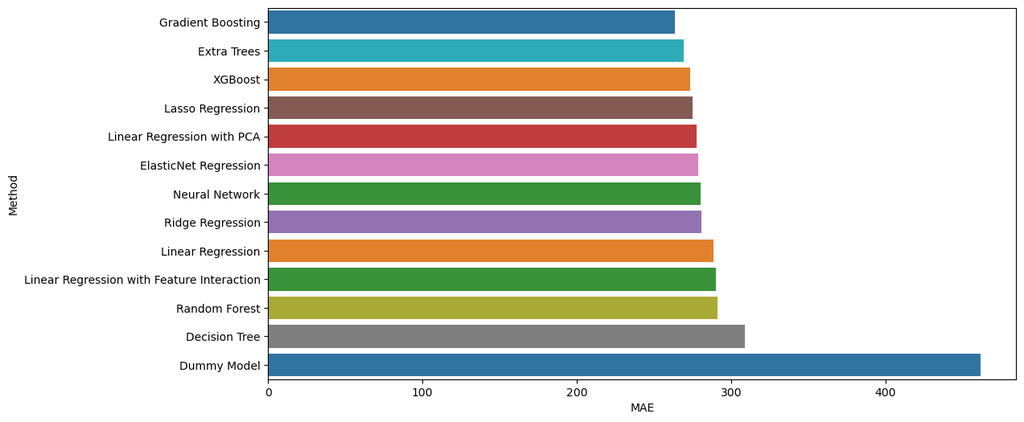

```python
palette = sns.color_palette("tab10", n_colors=len(metrics_df['Method'].unique()))
method_colors = dict(zip(metrics_df['Method'].unique(), palette))

plt.figure(figsize=(12, 6))
sns.barplot(data=metrics_df.sort_values(by='MAE', ascending=True), x='MAE', y='Method', hue='Method', legend=False, palette=method_colors)
plt.xlabel('MAE')
plt.ylabel('Method')
plt.show()
```

**-> Best model**: Gradient Boosting

**Training time of models** (*logarithmic scale*):

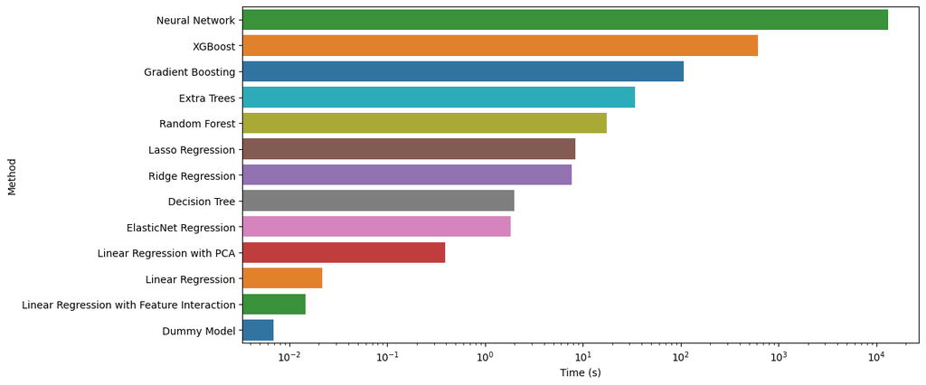

```python
plt.figure(figsize=(12, 6))
sns.barplot(data=metrics_df.sort_values(by='Time', ascending=False), x='Time', y='Method', hue='Method', legend=False, palette=method_colors)
plt.xlabel('Time (s)')
plt.ylabel('Method')
plt.xscale('log')  # Logarithmic scale, to see better the differences!
plt.show()
```

The best model, Gradient Boosting, shows a really good balance between quality (smaller MAE) and training time (much smaller than the multi-layer perceptron).

### Estimation of future performance

For estimating how well this model will perform for new, unseen data, we will calculate the MAE for the test partition that we did before:

```python
# Best GB regressor
gb_regressor_b = GradientBoostingRegressor(random_state=RANDOM_SEED, **gb_metrics['Params'])

# Fit and predict
gb_regressor_b.fit(X_train, y_train)
y_pred = gb_regressor_b.predict(X_test)
test_mae = mean_absolute_error(y_test, y_pred)
print("Estimation of future performance for the final model: MAE =", test_mae)
```

```
Estimation of future performance for the final model: MAE = 232.08419209390777
```

It is a very good MAE, comparing it with the values that we have seen until now. For our final model, this will be the "pesimistical" estimation of future performance.

### HPO with the whole dataset

And now that we have this estimation of future performance, we are going to take the whole dataset (except the prediction dataset without response, of course) to do a final hyper-parameter optimization and get the **final model**:

```python
def objective(trial):

    params = {
        "n_estimators": trial.suggest_int("n_estimators", 50, 200),
        "learning_rate": trial.suggest_float("learning_rate", 0.001, 0.2, log=True),
        "max_depth": trial.suggest_int("max_depth", 2, 20),
        "min_samples_split": trial.suggest_int("min_samples_split", 2, 20),
        "min_samples_leaf": trial.suggest_int("min_samples_leaf", 1, 10),
        "subsample": trial.suggest_float("subsample", 0.5, 1.0),
        "max_features": trial.suggest_categorical("max_features", [None, "sqrt", "log2"]),
    }

    final_regressor = GradientBoostingRegressor(random_state=RANDOM_SEED, **params)

    inner_score = cross_val_score(final_regressor, X, y, cv=inner, scoring='neg_mean_absolute_error').mean()
    mean_mae = - inner_score

    return mean_mae

study = optuna.create_study(direction='minimize', sampler=optuna.samplers.TPESampler(seed=RANDOM_SEED))
start_time = time.time()
study.optimize(objective, n_trials=5000)
```

```python
# Store final CV MAE
final_mae = study.best_value

# Store parameters
final_params = study.best_params

# Train the regressor with the final best parameters: this is our final model trained
final_regressor = GradientBoostingRegressor(random_state=RANDOM_SEED, **final_params)
final_regressor.fit(X, y)

# Print info
print("CV MAE for the final model:", final_mae)
print("Parameters of the final model:", final_params)
```

```
CV MAE for the final model: 235.71362129383087
Parameters of the final model: {'n_estimators': 188, 'learning_rate': 0.08279927900691572, 'max_depth': 14, 'min_samples_split': 7, 'min_samples_leaf': 6, 'subsample': 0.5143034175584628, 'max_features': 'log2'}
```

### Final predictions

With this final model we will do the predictions for the `prediction_data`:

```python
prediction_data.head()
```

|  | Monday_date | Stores | Affiliates_investment | Meta_investment | sea_brand | sea_other_investment | tiktok_investment | web_visits | GBP | Database_investment | OOH_investment | TV_hbtv_investment | TV_investment | Radio_investment | Year | Month | Week_Number | Week_Sales |
| --- | --- | --- | --- | --- | --- | --- | --- | --- | --- | --- | --- | --- | --- | --- | --- | --- | --- | --- |
| 117 | 2024-04-01 | 387 | 6117.0 | 26999.780009 | 18822.06 | 76230.434755 | 0.0 | 116425 | 10509 | 7350.0 | 15260.0625 | 6774.193548 | 75717.5125 | 29975.443232 | 2024 | 4 | 14 | 3065.5 |
| 118 | 2024-04-08 | 387 | 11912.4 | 25441.899993 | 19424.21 | 78370.290000 | 0.0 | 122924 | 10778 | 7350.0 | 15260.0625 | 6774.193548 | 75717.5125 | 29975.443232 | 2024 | 4 | 15 | 3223.0 |
| 119 | 2024-04-15 | 387 | 9560.8 | 25334.830005 | 29562.08 | 73387.790000 | 0.0 | 125179 | 11416 | 7350.0 | 15260.0625 | 6774.193548 | 71819.2925 | 34237.988711 | 2024 | 4 | 16 | 4137.0 |
| 120 | 2024-04-22 | 387 | 2924.9 | 27426.230010 | 15634.89 | 44404.670000 | 0.0 | 113752 | 11280 | 7350.0 | 16383.4250 | 6774.193548 | 71819.2925 | 47811.197423 | 2024 | 4 | 17 | 4499.0 |
| 121 | 2024-04-29 | 387 | 8721.6 | 26587.769989 | 29125.57 | 75271.840000 | 0.0 | 122473 | 8548 | 7350.0 | 16383.4250 | 6774.193548 | 71819.2925 | 21491.641991 | 2024 | 4 | 18 | 3433.5 |

Use `final_regressor` to predict and assign the prediction as the column `Sales`:

```python
# Use the same predictors
X_pred = prediction_data[predictors]

# Predict:
y_pred = final_regressor.predict(X_pred)
prediction_data['Sales'] = y_pred

# Show head. Sales columns now is computed.
prediction_data.head()
```

|  | Monday_date | Stores | Affiliates_investment | Meta_investment | sea_brand | sea_other_investment | tiktok_investment | web_visits | GBP | Database_investment | OOH_investment | TV_hbtv_investment | TV_investment | Radio_investment | Year | Month | Week_Number | Week_Sales | Sales |
| --- | --- | --- | --- | --- | --- | --- | --- | --- | --- | --- | --- | --- | --- | --- | --- | --- | --- | --- | --- |
| 117 | 2024-04-01 | 387 | 6117.0 | 26999.780009 | 18822.06 | 76230.434755 | 0.0 | 116425 | 10509 | 7350.0 | 15260.0625 | 6774.193548 | 75717.5125 | 29975.443232 | 2024 | 4 | 14 | 3065.5 | 4019.668021 |
| 118 | 2024-04-08 | 387 | 11912.4 | 25441.899993 | 19424.21 | 78370.290000 | 0.0 | 122924 | 10778 | 7350.0 | 15260.0625 | 6774.193548 | 75717.5125 | 29975.443232 | 2024 | 4 | 15 | 3223.0 | 4073.938915 |
| 119 | 2024-04-15 | 387 | 9560.8 | 25334.830005 | 29562.08 | 73387.790000 | 0.0 | 125179 | 11416 | 7350.0 | 15260.0625 | 6774.193548 | 71819.2925 | 34237.988711 | 2024 | 4 | 16 | 4137.0 | 4393.238705 |
| 120 | 2024-04-22 | 387 | 2924.9 | 27426.230010 | 15634.89 | 44404.670000 | 0.0 | 113752 | 11280 | 7350.0 | 16383.4250 | 6774.193548 | 71819.2925 | 47811.197423 | 2024 | 4 | 17 | 4499.0 | 4412.902689 |
| 121 | 2024-04-29 | 387 | 8721.6 | 26587.769989 | 29125.57 | 75271.840000 | 0.0 | 122473 | 8548 | 7350.0 | 16383.4250 | 6774.193548 | 71819.2925 | 21491.641991 | 2024 | 4 | 18 | 3433.5 | 3700.130384 |

```python
# Keep only the two columns needed
final_predictions = prediction_data[['Monday_date', 'Sales']]

# Save it as .csv
final_predictions.to_csv('final_prediction.csv', index=False)
```

### Insights

Finally, with this final model that we have obtained, we will obtaine some final insights. During all the project we have been learning about our predictors (focusing on the investment variables). Now, we are going to study how our definitive and best model treats the features.

#### Feature Importances

From `GradientBoostingRegressor` we can extract the feature importances, which are computed based on the total reduction of impurity (in our case, Friedman MSE, as this method only allows this criterion and MSE).

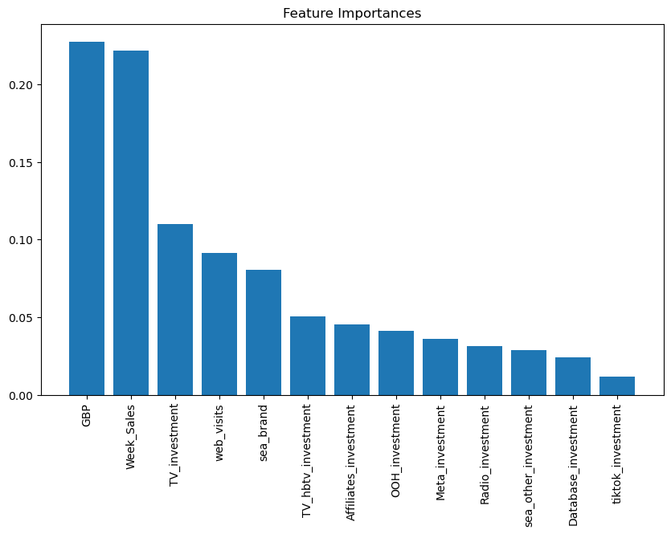

```python
# Get feature importances
feature_importances = final_regressor.feature_importances_

# Sort and plot
indices = np.argsort(feature_importances)[::-1]
plt.figure(figsize=(10, 6))
plt.bar(range(len(feature_importances)), feature_importances[indices], align="center")
plt.xticks(range(len(feature_importances)), np.array(predictors)[indices], rotation=90)
plt.title("Feature Importances")
plt.show()
```

The order of importance is similar to what we have been seeing until now, with `TV_invesment` (not `TV_hbtv_investment`) being the most relevant investment feature. However, it is interesting that the most important feature for this final model is nor `Week_Sales` as in the previous ones (although it is very near): it is `GBP`. As this feature is related to some money quantity (for example, some investment), it is very relevant for the business that `Sales` depend quite a lot on it.

The rest of the predictors were also used by the model, only that in a smaller degree. Other interesing non-investment predictors are `web_visits` and `sea_brand`, which were quite useful for the model.

#### Partial Dependence Plots

For getting more information, apart from the feature importances, we can use `PartialDependenceDisplay` from sklearn to see the partial dependences for all the predictors, ordered by feature importance:

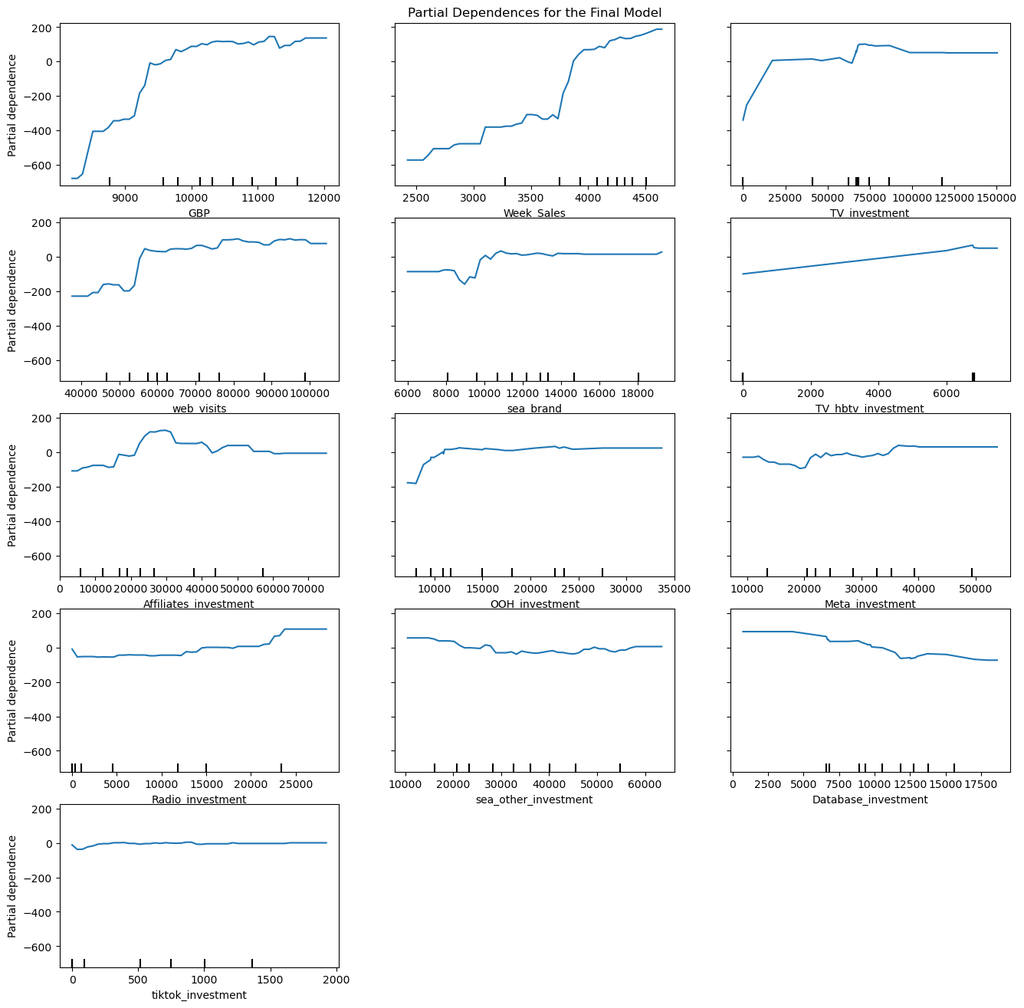

```python
# Create partial dependence plots
features_to_plot = np.array(predictors)[indices]

fig, ax = plt.subplots(figsize=(16, 16))
ax.set_title("Partial Dependences for the Final Model")
PartialDependenceDisplay.from_estimator(
    final_regressor,
    X_train,
    features=features_to_plot,
    feature_names=predictors,
    grid_resolution=50,
    ax=ax
)
plt.show()
```

We can check the form of the positive relationships between `Sales` and the non-invesment predictors `GBP`, `Week_Sales` and `web_visits`; and the more relevant investment predictors `TV_investment`, `TV_hbtv_investment` and `Affiliates_investment`. The other relationships are not as clearly positive and simple as that, showing how investment in these fields may not impact directly the number of `Sales`.

#### SHAP

SHAP (SHapley Additive exPlanations) is a popular framework for explaining general machine learning models predictions based in game theory (specifically, the Shapley value concept, which assigns a fair value to each predictor based on its contribution to the final outcome). This can provide a explanation of predictors relevance in a different way than the previous feature importance that we have done.

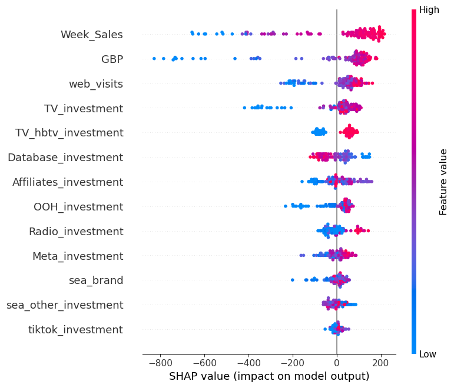

```python
# Initialize the explainer
explainer = shap.Explainer(final_regressor, X)

# Calculate SHAP values
shap_values = explainer(X)

# Summary plot
shap.summary_plot(shap_values, X, feature_names=predictors)
```

Again, we see a similar order to all the previous analysis, which reinforces the insights that we have for the predictors relevance.

#### Prediction Residuals

Just for checking, we are going to plot the residual to see if they are evenly distributed around 0:

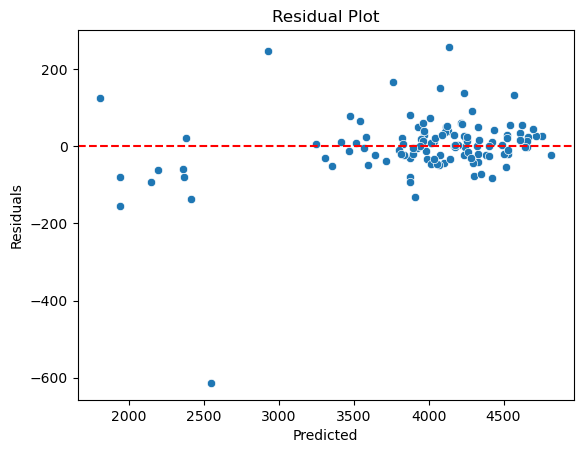

```python
# Calculate residuals
predictions = final_regressor.predict(X)
residuals = y - predictions

# Plot residuals
sns.scatterplot(x=predictions, y=residuals)
plt.axhline(0, color="red", linestyle="--")
plt.xlabel("Predicted")
plt.ylabel("Residuals")
plt.title("Residual Plot")
plt.show()
```

They are, showing the robustness of our model.

#### Plot tree

And, although our final model is made of 188 decision trees and we cannot plot every one of them, we can plot the first three just to get an idea of how the model looks "behind the scenes":

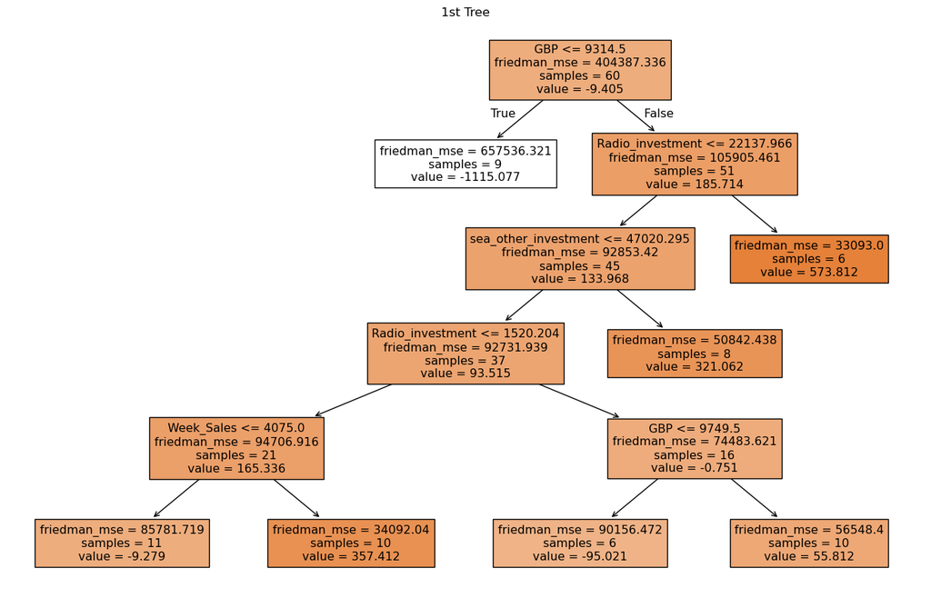

```python
# First tree
plt.figure(figsize=(16, 10))
plot_tree(final_regressor.estimators_[0, 0], feature_names=predictors, filled=True)
plt.title('1st Tree')
#plt.savefig("tree0.png", format="png", dpi=300)
plt.show()
```

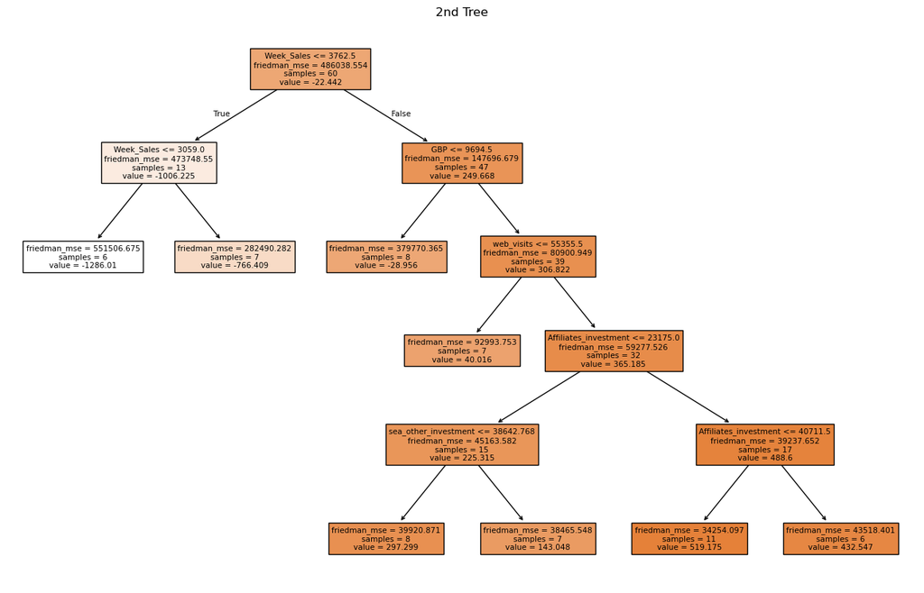

```python
# Second tree
plt.figure(figsize=(16, 10))
plot_tree(final_regressor.estimators_[1, 0], feature_names=predictors, filled=True)
plt.title('2nd Tree')
#plt.savefig("tree1.png", format="png", dpi=300)
plt.show()
```

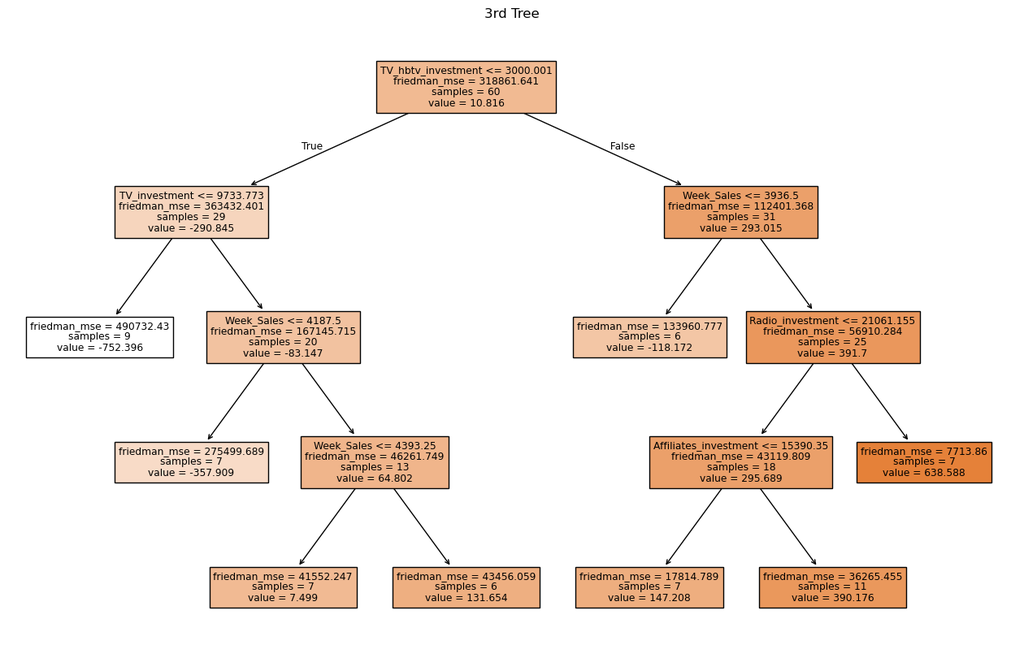

```python
# Third tree
plt.figure(figsize=(16, 10))
plot_tree(final_regressor.estimators_[2, 0], feature_names=predictors, filled=True)
plt.title('3rd Tree')
#plt.savefig("tree2.png", format="png", dpi=300)
plt.show()
```

The model uses the relevant features the most, showing how splitting nodes with it can lead to final nodes with good prediction values.

#### Conclusions

Let's sum up the explanations regarding variables affecting `Sales` that we have learned along the project: